# Análisis Descriptivo información del portal de datos públicos de Medellín (MEData).

## Caracterización de los agresores

#### Distribución por sexo

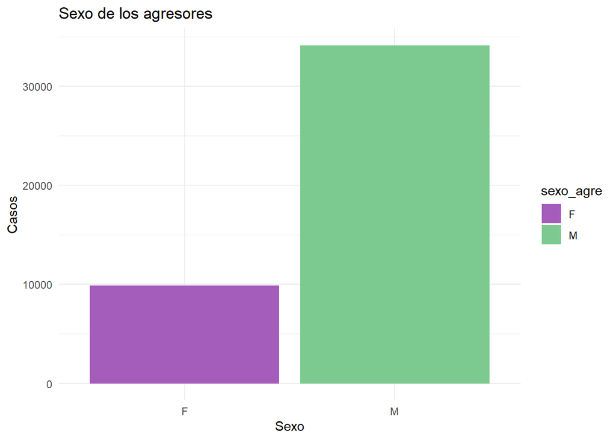

**¿cómo se comporta la violencia de género hacia la mujer dada por una misma mujer**

Es una observación interesante y relevante para el análisis de la violencia de género. Aunque la violencia contra mujeres, niñas y adolescentes suele ser mayoritariamente perpetrada por hombres, existen situaciones en las que las agresoras también son mujeres. Algunas explicaciones posibles incluyen:

*1. Violencia en el Ámbito Familiar* - Violencia intrafamiliar: En algunos casos, madres, abuelas u otras figuras femeninas pueden ejercer violencia contra niñas y adolescentes en contextos de disciplina severa o abuso.

- Conflictos interfamiliares: Puede haber disputas entre mujeres dentro de la familia que derivan en violencia psicológica, física o económica.

*2. Violencia en el Ámbito Laboral o Escolar* - Acoso laboral o bullying: En ambientes de trabajo o estudio, puede haber casos de acoso entre mujeres, incluyendo agresiones verbales, discriminación o exclusión.

- Ejercicio de poder en roles de liderazgo: En algunos casos, mujeres en posiciones de autoridad pueden ejercer violencia contra otras mujeres a través de abuso de poder.

*3. Trata de Personas y Explotación Sexual* - Algunas mujeres pueden desempeñar roles en redes de trata o explotación de otras mujeres, ya sea como reclutadoras o intermediarias dentro de estructuras más amplias de violencia de género.

*4. Violencia en Relaciones de Pareja* - En relaciones entre mujeres, pueden presentarse dinámicas de violencia de pareja similares a las que se observan en relaciones heterosexuales.

#### Relación víctima-agresor

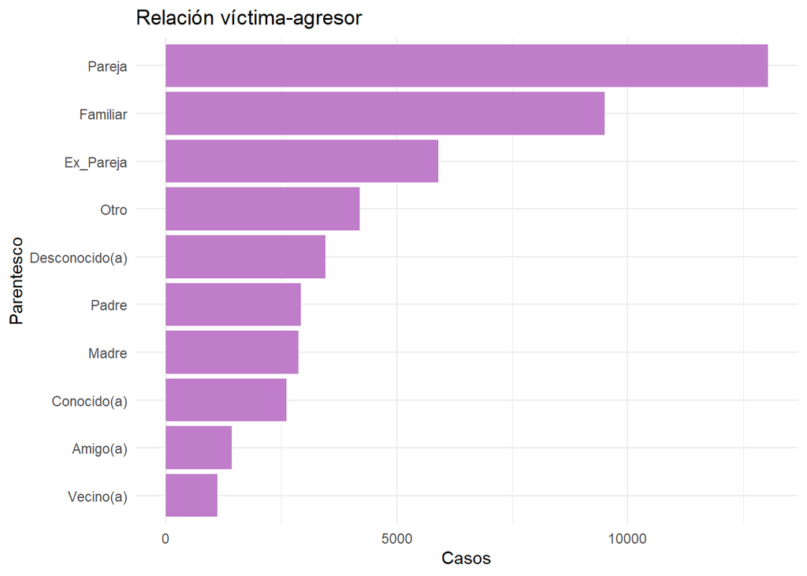

Con respecto a la relación que existe entre la víctima y el agresor, el análisis revela que, la violencia a la mujer está presentada mayormente por personas cercanas a la víctima. La pareja actual (12,696 casos) y familiares (9,213 casos) son los principales agresores, lo que resalta un preocupante patrón de violencia en el ámbito doméstico y relacional. Además, las exparejas (5,737 casos) representan un grupo significativo, lo que sugiere que el riesgo de violencia persiste incluso después de la finalización de la relación. Aunque en menor medida, la violencia ejercida por padres (2,878 casos) y madres (2,767 casos) también es relevante, evidenciando dinámicas de maltrato intrafamiliar. Seguido de eso se ve que la violencia también ocurre fuera del círculo familiar, pero con menor frecuencia.

#### Convive con el agresor

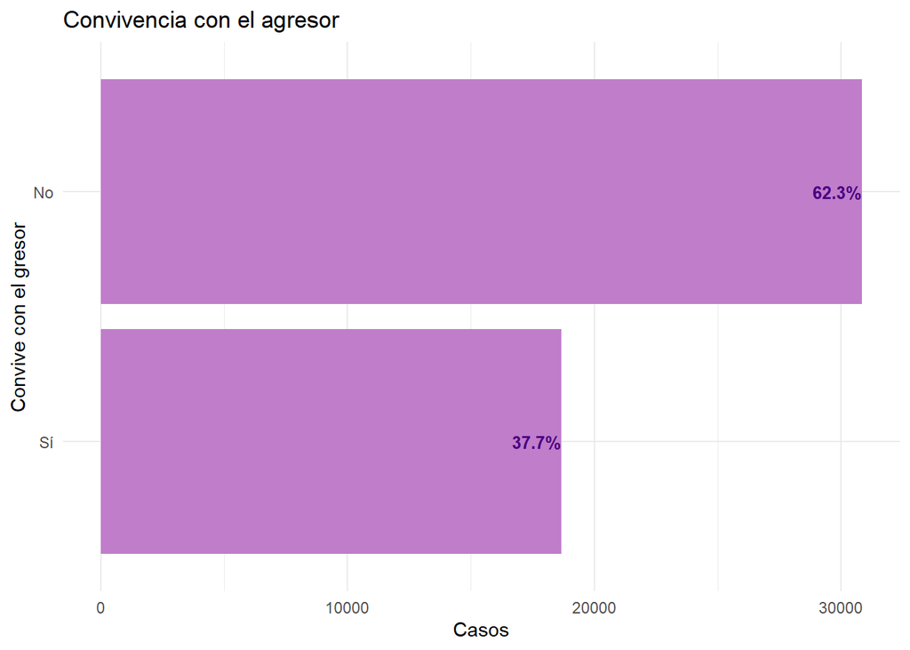

La mayoría de las víctimas no conviven con su agresor (62.31%), mientras que un 37.69% sí lo hace, lo que indica que una parte significativa de los casos de violencia ocurre dentro del mismo hogar o en espacios de convivencia cercana.

Esto sugiere que la violencia no solo es ejercida por personas con las que la víctima comparte un entorno diario, sino también por agresores externos, lo que podría incluir situaciones de violencia en espacios comunitarios, laborales o públicos. La alta proporción de convivencia con el agresor resalta la dificultad de muchas víctimas para denunciar, ya que pueden enfrentar miedo, dependencia económica o emocional, y barreras para acceder a apoyo y protección.

## Caracterización del hecho

#### Tipos de violencia reportados

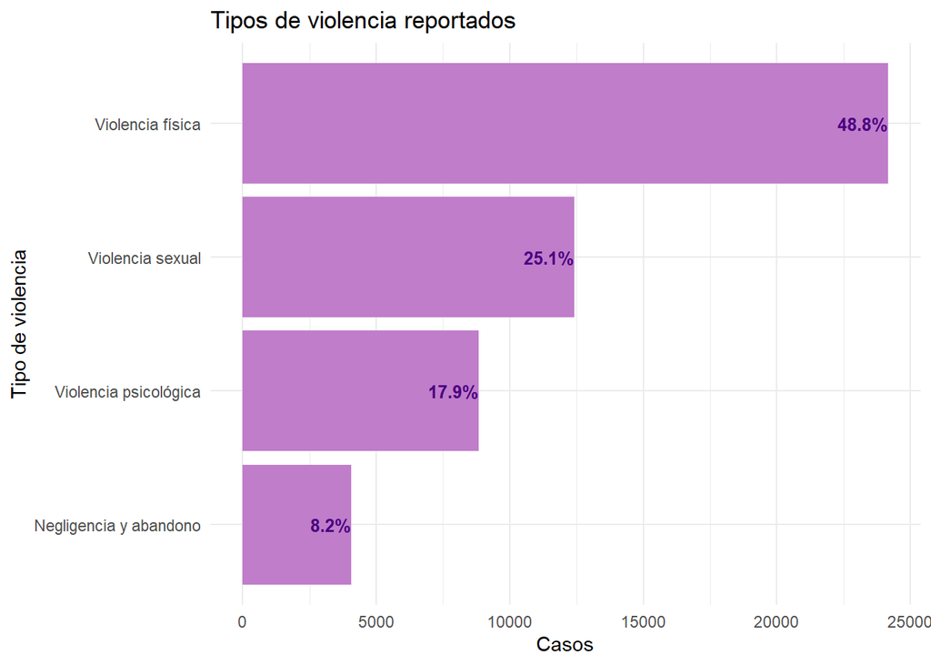

#### Área de ocurrencia

| area_ | n |
| --- | --- |
| Cabecera municipal | 48396 |
| Zona rural | 1107 |

El análisis sugiere que la violencia reportada ocurre principalmente en áreas urbanas, lo que puede estar relacionado con factores como mayor acceso a instituciones y disposición a denunciar. Sin embargo, la baja proporción de casos en la zona rural podría indicar una necesidad de mejorar mecanismos de acceso y apoyo para que las víctimas puedan denunciar con mayor facilidad.